# Beauty & Skincare Competitive Market Analysis

## Project Overview

This project evaluates six selected skincare brands using Sephora product data to understand competitive positioning across pricing, product portfolios, and customer response.

### Business Questions

1. How do competitors differ in pricing strategy?
2. Which brands maintain focused or diversified portfolios?
3. How does customer response vary across competitors?
4. Where might opportunities for differentiation exist?

### Dataset

Source: Sephora Products and Skincare Reviews (Kaggle)

Scope: 304 skincare products across six selected brands.

### Tools

Python, Pandas, Matplotlib

```python
import kagglehub

# Download latest version
path = kagglehub.dataset_download("nadyinky/sephora-products-and-skincare-reviews")

print("Path to dataset files:", path)
```

```python
import os

os.listdir(path)
```

```
['product_info.csv',
 'reviews_0-250.csv',
 'reviews_1250-end.csv',
 'reviews_750-1250.csv',
 'reviews_250-500.csv',
 'reviews_500-750.csv']
```

```python
import pandas as pd
import os

product_file = os.path.join(path, "product_info.csv")
products = pd.read_csv(product_file)

print(products.shape)
products.head()
```

```
(8494, 27)
```

|  | product_id | product_name | brand_id | brand_name | loves_count | rating | reviews | size | variation_type | variation_value | ... | online_only | out_of_stock | sephora_exclusive | highlights | primary_category | secondary_category | tertiary_category | child_count | child_max_price | child_min_price |
| --- | --- | --- | --- | --- | --- | --- | --- | --- | --- | --- | --- | --- | --- | --- | --- | --- | --- | --- | --- | --- | --- |
| 0 | P473671 | Fragrance Discovery Set | 6342 | 19-69 | 6320 | 3.6364 | 11.0 | NaN | NaN | NaN | ... | 1 | 0 | 0 | ['Unisex/ Genderless Scent', 'Warm &Spicy Scen... | Fragrance | Value & Gift Sets | Perfume Gift Sets | 0 | NaN | NaN |
| 1 | P473668 | La Habana Eau de Parfum | 6342 | 19-69 | 3827 | 4.1538 | 13.0 | 3.4 oz/ 100 mL | Size + Concentration + Formulation | 3.4 oz/ 100 mL | ... | 1 | 0 | 0 | ['Unisex/ Genderless Scent', 'Layerable Scent'... | Fragrance | Women | Perfume | 2 | 85.0 | 30.0 |
| 2 | P473662 | Rainbow Bar Eau de Parfum | 6342 | 19-69 | 3253 | 4.2500 | 16.0 | 3.4 oz/ 100 mL | Size + Concentration + Formulation | 3.4 oz/ 100 mL | ... | 1 | 0 | 0 | ['Unisex/ Genderless Scent', 'Layerable Scent'... | Fragrance | Women | Perfume | 2 | 75.0 | 30.0 |
| 3 | P473660 | Kasbah Eau de Parfum | 6342 | 19-69 | 3018 | 4.4762 | 21.0 | 3.4 oz/ 100 mL | Size + Concentration + Formulation | 3.4 oz/ 100 mL | ... | 1 | 0 | 0 | ['Unisex/ Genderless Scent', 'Layerable Scent'... | Fragrance | Women | Perfume | 2 | 75.0 | 30.0 |
| 4 | P473658 | Purple Haze Eau de Parfum | 6342 | 19-69 | 2691 | 3.2308 | 13.0 | 3.4 oz/ 100 mL | Size + Concentration + Formulation | 3.4 oz/ 100 mL | ... | 1 | 0 | 0 | ['Unisex/ Genderless Scent', 'Layerable Scent'... | Fragrance | Women | Perfume | 2 | 75.0 | 30.0 |

5 rows × 27 columns

```python
products.info()
```

```
<class 'pandas.core.frame.DataFrame'>
RangeIndex: 8494 entries, 0 to 8493
Data columns (total 27 columns):
 #   Column              Non-Null Count  Dtype
---  ------              --------------  -----
 0   product_id          8494 non-null   object
 1   product_name        8494 non-null   object
 2   brand_id            8494 non-null   int64
 3   brand_name          8494 non-null   object
 4   loves_count         8494 non-null   int64
 5   rating              8216 non-null   float64
 6   reviews             8216 non-null   float64
 7   size                6863 non-null   object
 8   variation_type      7050 non-null   object
 9   variation_value     6896 non-null   object
```

[output cut: 19 more lines]

```python
products.columns.tolist()
```

```
['product_id',
 'product_name',
 'brand_id',
 'brand_name',
 'loves_count',
 'rating',
 'reviews',
 'size',
 'variation_type',
 'variation_value',
 'variation_desc',
 'ingredients',
 'price_usd',
 'value_price_usd',
 'sale_price_usd',
 'limited_edition',
 'new',
 'online_only',
 'out_of_stock',
 'sephora_exclusive',
 'highlights',
 'primary_category',
 'secondary_category',
 'tertiary_category',
 'child_count',
 'child_max_price',
 'child_min_price']
```

```python
products["primary_category"].value_counts()
```

```
primary_category
Skincare           2420
Makeup             2369
Hair               1464
Fragrance          1432
Bath & Body         405
Mini Size           288
Men                  60
Tools & Brushes      52
Gifts                 4
Name: count, dtype: int64
```

```python
skincare = products[
    products["primary_category"] == "Skincare"
].copy()

print(skincare.shape)
```

```
(2420, 27)
```

```python
# Number of skincare brands
print("Number of brands:", skincare["brand_name"].nunique())

# Top brands by number of products
print("\nTop brands by product count:")
print(skincare["brand_name"].value_counts().head(20))

# Secondary category distribution
print("\nSecondary categories:")
print(skincare["secondary_category"].value_counts())

# Tertiary category distribution
print("\nTertiary categories:")
print(skincare["tertiary_category"].value_counts())
```

```
Number of brands: 143

Top brands by product count:
brand_name
SEPHORA COLLECTION    96
CLINIQUE              90
Peter Thomas Roth     58
Shiseido              56
Kiehl's Since 1851    53
fresh                 50
Murad                 48
Dermalogica           48
The Ordinary          45
Kate Somerville       43
Tatcha                42
Mario Badescu         41
The INKEY List        41
Dr. Jart+             40
Dr. Barbara Sturm     39
Origins               38
Drunk Elephant        38
Paula's Choice        37
Caudalie              37
Supergoop!            36
Name: count, dtype: int64

Secondary categories:
secondary_category
Moisturizers              551
Treatments                466
Cleansers                 361
Value & Gift Sets         196
Eye Care                  186
Masks                     166
Mini Size                 112
Sunscreen                 108
High Tech Tools            80
Wellness                   79
Lip Balms & Treatments     61
Self Tanners               53
```

[output cut: 21 more lines]

```
Facial Rollers                25
For Face                      18
Night Creams                  17
Eye Masks                     14
Facial Cleansing Brushes      13
Decollete & Neck Creams       10
Body Sunscreen                10
Makeup Removers               10
Hair Removal                  10
Holistic Wellness             10
Face Wipes                     6
Teeth Whitening                5
Blotting Papers                4
BB & CC Creams                 4
Name: count, dtype: int64
```

```python
selected_brands = [
    "CLINIQUE",
    "Kiehl's Since 1851",
    "The Ordinary",
    "The INKEY List",
    "Drunk Elephant",
    "Paula's Choice"
]

competitors = skincare[
    skincare["brand_name"].isin(selected_brands)
].copy()

category_matrix = pd.crosstab(
    competitors["brand_name"],
    competitors["secondary_category"]
)

category_matrix
```

| secondary_category brand_name | Cleansers | Eye Care | High Tech Tools | Lip Balms & Treatments | Masks | Mini Size | Moisturizers | Self Tanners | Sunscreen | Treatments | Value & Gift Sets |
| --- | --- | --- | --- | --- | --- | --- | --- | --- | --- | --- | --- |
| CLINIQUE | 23 | 9 | 1 | 2 | 3 | 2 | 25 | 1 | 5 | 12 | 7 |
| Drunk Elephant | 5 | 3 | 0 | 1 | 2 | 4 | 6 | 0 | 2 | 8 | 7 |
| Kiehl's Since 1851 | 11 | 3 | 0 | 1 | 4 | 4 | 14 | 0 | 1 | 10 | 5 |
| Paula's Choice | 9 | 2 | 0 | 1 | 0 | 1 | 6 | 0 | 3 | 13 | 2 |
| The INKEY List | 9 | 3 | 0 | 0 | 1 | 0 | 7 | 0 | 1 | 19 | 1 |
| The Ordinary | 4 | 1 | 0 | 0 | 1 | 0 | 4 | 0 | 0 | 33 | 2 |

```python
competitor_summary = competitors.groupby("brand_name").agg(
    Products=("product_id", "count"),
    Avg_Price=("price_usd", "mean"),
    Median_Price=("price_usd", "median"),
    Avg_Rating=("rating", "mean"),
    Total_Reviews=("reviews", "sum"),
    Total_Loves=("loves_count", "sum")
).round(2)

competitor_summary
```

| brand_name | Products | Avg_Price | Median_Price | Avg_Rating | Total_Reviews | Total_Loves |
| --- | --- | --- | --- | --- | --- | --- |
| CLINIQUE | 90 | 40.31 | 34.75 | 4.03 | 49016.0 | 1701952 |
| Drunk Elephant | 38 | 45.82 | 38.00 | 4.13 | 42331.0 | 3615978 |
| Kiehl's Since 1851 | 53 | 48.87 | 46.00 | 4.24 | 21698.0 | 1383848 |
| Paula's Choice | 37 | 40.00 | 37.00 | 4.40 | 6408.0 | 1177465 |
| The INKEY List | 41 | 13.44 | 12.99 | 4.09 | 25500.0 | 2201657 |
| The Ordinary | 45 | 12.20 | 10.00 | 4.18 | 35785.0 | 6628060 |

# 2. Data Cleaning & Validation

```python
# Create working dataset for the six selected competitors
analysis_df = competitors.copy()

print("Dataset shape:", analysis_df.shape)
print("\nDuplicate product IDs:", analysis_df["product_id"].duplicated().sum())

print("\nMissing values:")
print(
    analysis_df[
        [
            "product_id",
            "product_name",
            "brand_name",
            "price_usd",
            "rating",
            "reviews",
            "loves_count",
            "secondary_category",
            "tertiary_category"
        ]
    ].isna().sum()
)

print("\nPrice summary:")
print(analysis_df["price_usd"].describe())

print("\nRating summary:")
print(analysis_df["rating"].describe())

print("\nReview summary:")
print(analysis_df["reviews"].describe())
```

```
Dataset shape: (304, 27)

Duplicate product IDs: 0

Missing values:
product_id             0
product_name           0
brand_name             0
price_usd              0
rating                 9
reviews                9
loves_count            0
secondary_category     0
tertiary_category     40
dtype: int64

Price summary:
count    304.000000
mean      34.667105
std       21.647228
min        5.000000
25%       15.990000
50%       32.000000
75%       47.250000
max      125.000000
Name: price_usd, dtype: float64

Rating summary:
count    295.000000
mean       4.154907
std        0.417176
min        2.000000
25%        3.925600
50%        4.219400
75%        4.435650
max        5.000000
Name: rating, dtype: float64

Review summary:
count     295.000000
mean      612.671186
std       903.563093
min         1.000000
25%        82.500000
50%       247.000000
75%       735.500000
max      6048.000000
Name: reviews, dtype: float64
```

```python
# Validation checks

print("Invalid prices:", (analysis_df["price_usd"] <= 0).sum())

print(
    "Invalid ratings:",
    ((analysis_df["rating"] < 0) | (analysis_df["rating"] > 5)).sum()
)

print(
    "Invalid review counts:",
    (analysis_df["reviews"] < 0).sum()
)

print(
    "Invalid loves counts:",
    (analysis_df["loves_count"] < 0).sum()
)
```

```
Invalid prices: 0
Invalid ratings: 0
Invalid review counts: 0
Invalid loves counts: 0
```

```python
customer_response_df = analysis_df.dropna(
    subset=["rating", "reviews"]
).copy()

print("Full analysis dataset:", analysis_df.shape)
print("Customer response dataset:", customer_response_df.shape)
```

```
Full analysis dataset: (304, 27)
Customer response dataset: (295, 27)
```

### Data Cleaning Decisions

- No duplicate product IDs were identified.
- All 304 products contained valid price information and were retained for pricing and portfolio analysis.
- Nine products had missing rating and review information. These products were retained in the master dataset but excluded from customer-response analyses requiring rating or review metrics.
- Missing tertiary category values were retained because secondary category information was complete and sufficient for the primary portfolio analysis.
- No products were removed solely based on high prices, as premium pricing may represent legitimate brand positioning rather than a data-quality issue.

# 3. Competitive Analysis

## 3.1 Pricing & Positioning

This section evaluates how the six selected skincare brands are positioned across different price levels and examines differences in pricing strategy across their product portfolios.

```python
pricing_summary = analysis_df.groupby("brand_name").agg(
    Product_Count=("product_id", "count"),
    Avg_Price=("price_usd", "mean"),
    Median_Price=("price_usd", "median"),
    Min_Price=("price_usd", "min"),
    Max_Price=("price_usd", "max")
).round(2)

pricing_summary = pricing_summary.sort_values(
    "Median_Price",
    ascending=False
)

pricing_summary
```

| brand_name | Product_Count | Avg_Price | Median_Price | Min_Price | Max_Price |
| --- | --- | --- | --- | --- | --- |
| Kiehl's Since 1851 | 53 | 48.87 | 46.00 | 18.00 | 125.0 |
| Drunk Elephant | 38 | 45.82 | 38.00 | 14.00 | 90.0 |
| Paula's Choice | 37 | 40.00 | 37.00 | 13.00 | 75.0 |
| CLINIQUE | 90 | 40.31 | 34.75 | 11.00 | 85.0 |
| The INKEY List | 41 | 13.44 | 12.99 | 5.99 | 27.0 |
| The Ordinary | 45 | 12.20 | 10.00 | 5.00 | 40.7 |

```python
analysis_df.groupby("brand_name")["price_usd"].describe().round(2)
```

| brand_name | count | mean | std | min | 25% | 50% | 75% | max |
| --- | --- | --- | --- | --- | --- | --- | --- | --- |
| CLINIQUE | 90.0 | 40.31 | 18.09 | 11.00 | 26.50 | 34.75 | 53.00 | 85.0 |
| Drunk Elephant | 38.0 | 45.82 | 22.49 | 14.00 | 28.00 | 38.00 | 67.00 | 90.0 |
| Kiehl's Since 1851 | 53.0 | 48.87 | 21.38 | 18.00 | 35.00 | 46.00 | 60.00 | 125.0 |
| Paula's Choice | 37.0 | 40.00 | 13.68 | 13.00 | 34.00 | 37.00 | 49.00 | 75.0 |
| The INKEY List | 41.0 | 13.44 | 4.24 | 5.99 | 10.99 | 12.99 | 15.99 | 27.0 |
| The Ordinary | 45.0 | 12.20 | 7.38 | 5.00 | 7.80 | 10.00 | 12.50 | 40.7 |

```python
brand_colors = {
    "The Ordinary": "#1E4FA3",
    "The INKEY List": "#83B5F0",
    "CLINIQUE": "#3291B8",
    "Paula's Choice": "#7A6FC2",
    "Drunk Elephant": "#E48B8B",
    "Kiehl's Since 1851": "#D2A84A"
}
```

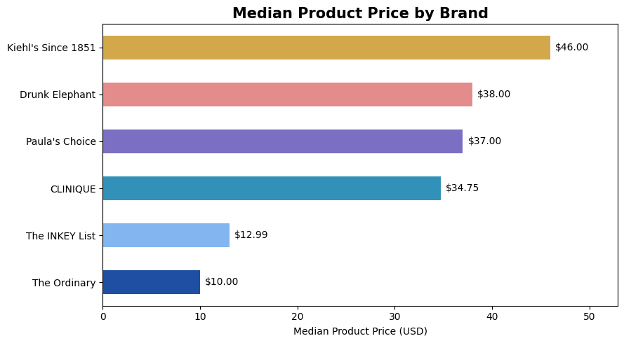

```python
import matplotlib.pyplot as plt

# Calculate median product price by brand
brand_price = (
    analysis_df.groupby("brand_name")["price_usd"]
    .median()
    .sort_values()
)

# Match each brand with its assigned color
bar_colors = [brand_colors[brand] for brand in brand_price.index]

# Create chart
plt.figure(figsize=(9, 5))

ax = brand_price.plot(
    kind="barh",
    color=bar_colors,
    edgecolor="none"
)

plt.title("Median Product Price by Brand", fontsize=15, fontweight="bold")
plt.xlabel("Median Product Price (USD)")
plt.ylabel("")

# Add price labels
for i, value in enumerate(brand_price):
    ax.text(
        value + 0.5,
        i,
        f"${value:.2f}",
        va="center",
        fontsize=10
    )

plt.xlim(0, brand_price.max() * 1.15)

plt.tight_layout()
plt.show()
```

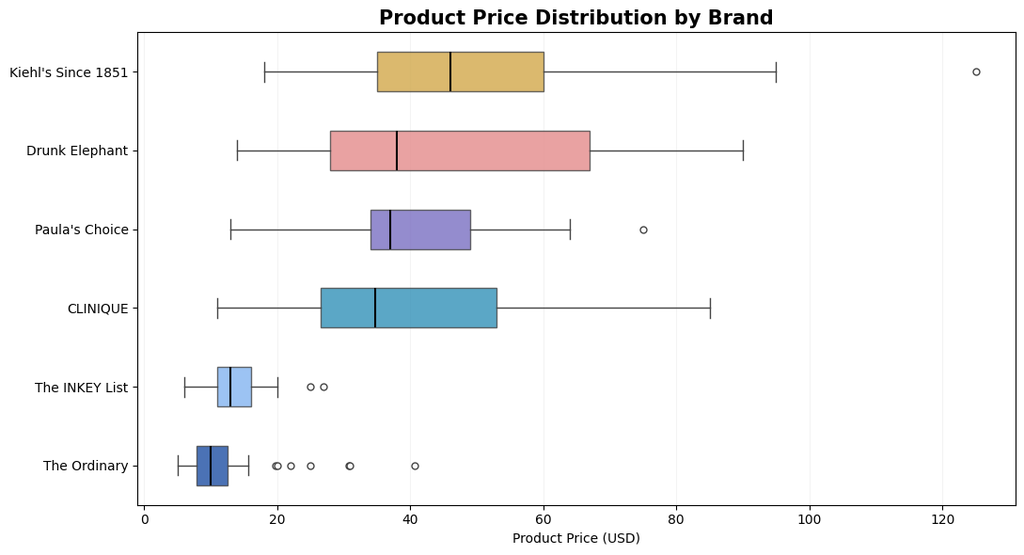

```python
import matplotlib.pyplot as plt

# Brand order
brand_order = [
    "Kiehl's Since 1851",
    "Drunk Elephant",
    "Paula's Choice",
    "CLINIQUE",
    "The INKEY List",
    "The Ordinary"
]

# Prepare price data
price_data = [
    analysis_df.loc[
        analysis_df["brand_name"] == brand,
        "price_usd"
    ].dropna()
    for brand in brand_order
]

# Create boxplot
fig, ax = plt.subplots(figsize=(11, 6))

bp = ax.boxplot(
    price_data,
    vert=False,
    patch_artist=True,
    tick_labels=brand_order,
    medianprops={"color": "black", "linewidth": 1.5},
    boxprops={"edgecolor": "#444444"},
    whiskerprops={"color": "#444444"},
    capprops={"color": "#444444"},
    flierprops={
        "marker": "o",
        "markerfacecolor": "white",
        "markeredgecolor": "#444444",
        "markersize": 5
    }
)

# Apply brand colors
for box, brand in zip(bp["boxes"], brand_order):
    box.set_facecolor(brand_colors[brand])
    box.set_alpha(0.8)

# Reverse Y-axis to match brand order
ax.invert_yaxis()

ax.set_title(
    "Product Price Distribution by Brand",
    fontsize=15,
    fontweight="bold"
)

ax.set_xlabel("Product Price (USD)")
ax.set_ylabel("")

ax.grid(axis="x", alpha=0.15)

plt.tight_layout()
plt.show()
```

### Initial Pricing Observation

The six competitors show two clearly differentiated pricing groups. The Ordinary and The INKEY List occupy an accessible price position, with median product prices of $10.00 and $12.99, respectively. In contrast, the four remaining competitors have median prices ranging from $34.75 to $46.00.

Kiehl's Since 1851 has the highest median price at $46.00, while The Ordinary has the lowest at $10.00. Price distributions also indicate substantially broader price ranges among the higher-priced brands.

## 3.2 Product Portfolio Analysis

This section compares the breadth and composition of each competitor's skincare portfolio to identify category priorities, areas of competitive overlap, and differences in product strategy.

```python
portfolio_summary = analysis_df.groupby("brand_name").agg(
    Product_Count=("product_id", "count"),
    Secondary_Categories=("secondary_category", "nunique"),
    Tertiary_Categories=("tertiary_category", "nunique")
).sort_values("Product_Count", ascending=False)

portfolio_summary
```

| brand_name | Product_Count | Secondary_Categories | Tertiary_Categories |
| --- | --- | --- | --- |
| CLINIQUE | 90 | 11 | 15 |
| Kiehl's Since 1851 | 53 | 9 | 10 |
| The Ordinary | 45 | 6 | 8 |
| The INKEY List | 41 | 7 | 10 |
| Drunk Elephant | 38 | 9 | 9 |
| Paula's Choice | 37 | 8 | 8 |

```python
category_counts = pd.crosstab(
    analysis_df["brand_name"],
    analysis_df["secondary_category"]
)

category_share = (
    category_counts
    .div(category_counts.sum(axis=1), axis=0)
    .mul(100)
    .round(1)
)

category_share
```

| secondary_category brand_name | Cleansers | Eye Care | High Tech Tools | Lip Balms & Treatments | Masks | Mini Size | Moisturizers | Self Tanners | Sunscreen | Treatments | Value & Gift Sets |
| --- | --- | --- | --- | --- | --- | --- | --- | --- | --- | --- | --- |
| CLINIQUE | 25.6 | 10.0 | 1.1 | 2.2 | 3.3 | 2.2 | 27.8 | 1.1 | 5.6 | 13.3 | 7.8 |
| Drunk Elephant | 13.2 | 7.9 | 0.0 | 2.6 | 5.3 | 10.5 | 15.8 | 0.0 | 5.3 | 21.1 | 18.4 |
| Kiehl's Since 1851 | 20.8 | 5.7 | 0.0 | 1.9 | 7.5 | 7.5 | 26.4 | 0.0 | 1.9 | 18.9 | 9.4 |
| Paula's Choice | 24.3 | 5.4 | 0.0 | 2.7 | 0.0 | 2.7 | 16.2 | 0.0 | 8.1 | 35.1 | 5.4 |
| The INKEY List | 22.0 | 7.3 | 0.0 | 0.0 | 2.4 | 0.0 | 17.1 | 0.0 | 2.4 | 46.3 | 2.4 |
| The Ordinary | 8.9 | 2.2 | 0.0 | 0.0 | 2.2 | 0.0 | 8.9 | 0.0 | 0.0 | 73.3 | 4.4 |

```python
top_categories = (
    analysis_df.groupby(["brand_name", "secondary_category"])
    .size()
    .reset_index(name="Product_Count")
)

top_categories["Portfolio_Share"] = (
    top_categories["Product_Count"]
    / top_categories.groupby("brand_name")["Product_Count"].transform("sum")
    * 100
).round(1)

top_3_categories = (
    top_categories
    .sort_values(
        ["brand_name", "Product_Count"],
        ascending=[True, False]
    )
    .groupby("brand_name")
    .head(3)
)

top_3_categories
```

|  | brand_name | secondary_category | Product_Count | Portfolio_Share |
| --- | --- | --- | --- | --- |
| 6 | CLINIQUE | Moisturizers | 25 | 27.8 |
| 0 | CLINIQUE | Cleansers | 23 | 25.6 |
| 9 | CLINIQUE | Treatments | 12 | 13.3 |
| 18 | Drunk Elephant | Treatments | 8 | 21.1 |
| 19 | Drunk Elephant | Value & Gift Sets | 7 | 18.4 |
| 16 | Drunk Elephant | Moisturizers | 6 | 15.8 |
| 25 | Kiehl's Since 1851 | Moisturizers | 14 | 26.4 |
| 20 | Kiehl's Since 1851 | Cleansers | 11 | 20.8 |
| 27 | Kiehl's Since 1851 | Treatments | 10 | 18.9 |
| 35 | Paula's Choice | Treatments | 13 | 35.1 |
| 29 | Paula's Choice | Cleansers | 9 | 24.3 |
| 33 | Paula's Choice | Moisturizers | 6 | 16.2 |
| 42 | The INKEY List | Treatments | 19 | 46.3 |
| 37 | The INKEY List | Cleansers | 9 | 22.0 |
| 40 | The INKEY List | Moisturizers | 7 | 17.1 |
| 48 | The Ordinary | Treatments | 33 | 73.3 |
| 44 | The Ordinary | Cleansers | 4 | 8.9 |
| 47 | The Ordinary | Moisturizers | 4 | 8.9 |

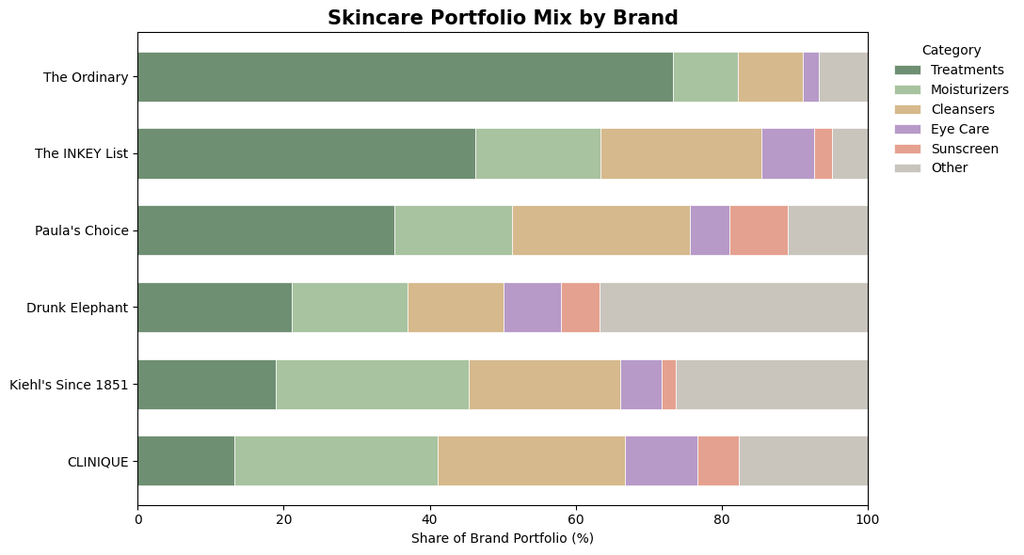

```python
import matplotlib.pyplot as plt

# ==========================================
# 1. Define core skincare categories
# ==========================================

core_categories = [
    "Treatments",
    "Moisturizers",
    "Cleansers",
    "Eye Care",
    "Sunscreen"
]

# Category colors
portfolio_colors = {
    "Treatments": "#6F8F72",      # Sage Green
    "Moisturizers": "#A8C3A0",    # Soft Green
    "Cleansers": "#D6B98C",       # Warm Beige
    "Eye Care": "#B79AC8",        # Soft Lavender
    "Sunscreen": "#E5A18F",       # Dusty Peach
    "Other": "#C9C5BC"            # Warm Gray
}

# ==========================================
# 2. Prepare portfolio data
# ==========================================

portfolio_plot = category_share[core_categories].copy()

portfolio_plot["Other"] = (
    100 - portfolio_plot.sum(axis=1)
).round(1)

# Order brands
brand_order = [
    "The Ordinary",
    "The INKEY List",
    "Paula's Choice",
    "Drunk Elephant",
    "Kiehl's Since 1851",
    "CLINIQUE"
]

portfolio_plot = portfolio_plot.loc[brand_order]

# Match category colors
plot_colors = [
    portfolio_colors[category]
    for category in portfolio_plot.columns
]

# ==========================================
# 3. Create stacked bar chart
# ==========================================

ax = portfolio_plot.plot(
    kind="barh",
    stacked=True,
    figsize=(11, 6),
    color=plot_colors,
    width=0.65,
    edgecolor="white",
    linewidth=0.5
)

ax.invert_yaxis()

plt.title(
    "Skincare Portfolio Mix by Brand",
    fontsize=15,
    fontweight="bold"
)

plt.xlabel("Share of Brand Portfolio (%)")
plt.ylabel("")

plt.xlim(0, 100)

plt.legend(
    title="Category",
    bbox_to_anchor=(1.02, 1),
    loc="upper left",
    frameon=False
)

plt.tight_layout()
plt.show()
```

```python
portfolio_concentration = pd.DataFrame({
    "Largest_Category": category_share.idxmax(axis=1),
    "Largest_Category_Share": category_share.max(axis=1)
}).sort_values(
    "Largest_Category_Share",
    ascending=False
)

portfolio_concentration
```

| brand_name | Largest_Category | Largest_Category_Share |
| --- | --- | --- |
| The Ordinary | Treatments | 73.3 |
| The INKEY List | Treatments | 46.3 |
| Paula's Choice | Treatments | 35.1 |
| CLINIQUE | Moisturizers | 27.8 |
| Kiehl's Since 1851 | Moisturizers | 26.4 |
| Drunk Elephant | Treatments | 21.1 |

### Initial Portfolio Observation

The competitors demonstrate substantially different portfolio strategies. CLINIQUE has the broadest product portfolio, with 90 products across 11 secondary skincare categories, while its largest category represents only 27.8% of the portfolio.

In contrast, The Ordinary shows a highly specialized portfolio structure, with 73.3% of its products classified as Treatments. The INKEY List also demonstrates a treatment-focused strategy, with Treatments representing 46.3% of its portfolio, followed by Paula's Choice at 35.1%.

These results indicate a spectrum from diversified skincare portfolios to more specialized, treatment-led product strategies.

## 3.3 Customer Response Analysis

This section evaluates customer response across the six selected competitors using product ratings, review volume, and Sephora loves. Products without rating or review information are excluded from metrics that require those fields.

```python
customer_summary = customer_response_df.groupby("brand_name").agg(
    Rated_Products=("product_id", "count"),
    Avg_Rating=("rating", "mean"),
    Median_Rating=("rating", "median"),
    Total_Reviews=("reviews", "sum"),
    Avg_Reviews_Per_Product=("reviews", "mean"),
    Total_Loves=("loves_count", "sum"),
    Avg_Loves_Per_Product=("loves_count", "mean")
).round(2)

customer_summary.sort_values(
    "Avg_Rating",
    ascending=False
)
```

| brand_name | Rated_Products | Avg_Rating | Median_Rating | Total_Reviews | Avg_Reviews_Per_Product | Total_Loves | Avg_Loves_Per_Product |
| --- | --- | --- | --- | --- | --- | --- | --- |
| Paula's Choice | 37 | 4.40 | 4.50 | 6408.0 | 173.19 | 1177465 | 31823.38 |
| Kiehl's Since 1851 | 46 | 4.24 | 4.31 | 21698.0 | 471.70 | 1383038 | 30066.04 |
| The Ordinary | 45 | 4.18 | 4.21 | 35785.0 | 795.22 | 6628060 | 147290.22 |
| Drunk Elephant | 38 | 4.13 | 4.22 | 42331.0 | 1113.97 | 3615978 | 95157.32 |
| The INKEY List | 41 | 4.09 | 4.16 | 25500.0 | 621.95 | 2201657 | 53698.95 |
| CLINIQUE | 88 | 4.03 | 4.16 | 49016.0 | 557.00 | 1699082 | 19307.75 |

```python
loves_summary = analysis_df.groupby("brand_name").agg(
    Total_Loves=("loves_count", "sum"),
    Avg_Loves_Per_Product=("loves_count", "mean"),
    Median_Loves_Per_Product=("loves_count", "median")
).round(2)

loves_summary.sort_values(
    "Total_Loves",
    ascending=False
)
```

| brand_name | Total_Loves | Avg_Loves_Per_Product | Median_Loves_Per_Product |
| --- | --- | --- | --- |
| The Ordinary | 6628060 | 147290.22 | 74003.0 |
| Drunk Elephant | 3615978 | 95157.32 | 48907.0 |
| The INKEY List | 2201657 | 53698.95 | 40474.0 |
| CLINIQUE | 1701952 | 18910.58 | 9205.0 |
| Kiehl's Since 1851 | 1383848 | 26110.34 | 17152.0 |
| Paula's Choice | 1177465 | 31823.38 | 15686.0 |

```python
reviews_summary = customer_response_df.groupby("brand_name").agg(
    Total_Reviews=("reviews", "sum"),
    Avg_Reviews_Per_Product=("reviews", "mean"),
    Median_Reviews_Per_Product=("reviews", "median")
).round(2)

reviews_summary.sort_values(
    "Total_Reviews",
    ascending=False
)
```

| brand_name | Total_Reviews | Avg_Reviews_Per_Product | Median_Reviews_Per_Product |
| --- | --- | --- | --- |
| CLINIQUE | 49016.0 | 557.00 | 190.0 |
| Drunk Elephant | 42331.0 | 1113.97 | 779.0 |
| The Ordinary | 35785.0 | 795.22 | 255.0 |
| The INKEY List | 25500.0 | 621.95 | 346.0 |
| Kiehl's Since 1851 | 21698.0 | 471.70 | 262.5 |
| Paula's Choice | 6408.0 | 173.19 | 133.0 |

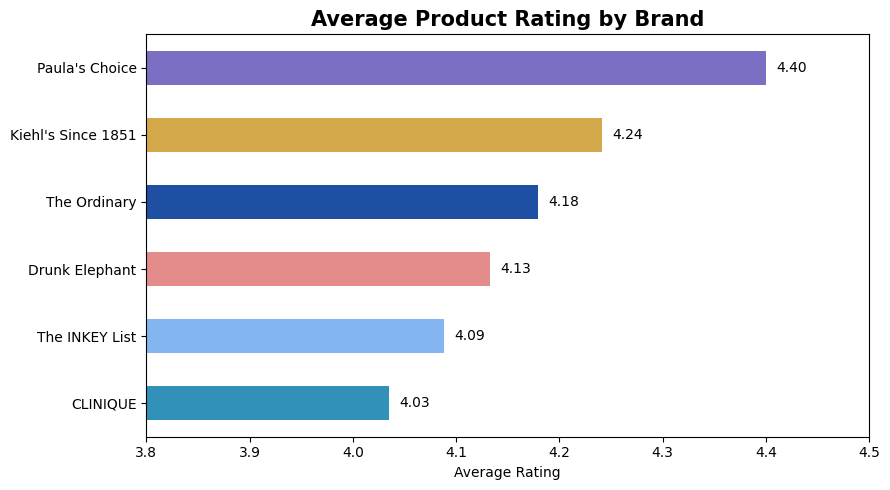

```python
import matplotlib.pyplot as plt

# Calculate average rating by brand
rating_plot = (
    customer_response_df.groupby("brand_name")["rating"]
    .mean()
    .sort_values()
)

# Match brand colors
bar_colors = [
    brand_colors[brand]
    for brand in rating_plot.index
]

# Create chart
fig, ax = plt.subplots(figsize=(9, 5))

rating_plot.plot(
    kind="barh",
    ax=ax,
    color=bar_colors,
    edgecolor="none"
)

plt.title(
    "Average Product Rating by Brand",
    fontsize=15,
    fontweight="bold"
)

plt.xlabel("Average Rating")
plt.ylabel("")

# Keep the original rating scale
plt.xlim(3.8, 4.5)

# Add rating labels
for i, value in enumerate(rating_plot):
    ax.text(
        value + 0.01,
        i,
        f"{value:.2f}",
        va="center",
        fontsize=10
    )

plt.tight_layout()
plt.show()
```

```python
engagement_summary = pd.DataFrame({
    "Avg_Reviews_Per_Product":
        customer_response_df.groupby("brand_name")["reviews"].mean(),
    "Avg_Loves_Per_Product":
        analysis_df.groupby("brand_name")["loves_count"].mean()
}).round(2)

engagement_summary.sort_values(
    "Avg_Loves_Per_Product",
    ascending=False
)
```

| brand_name | Avg_Reviews_Per_Product | Avg_Loves_Per_Product |
| --- | --- | --- |
| The Ordinary | 795.22 | 147290.22 |
| Drunk Elephant | 1113.97 | 95157.32 |
| The INKEY List | 621.95 | 53698.95 |
| Paula's Choice | 173.19 | 31823.38 |
| Kiehl's Since 1851 | 471.70 | 26110.34 |
| CLINIQUE | 557.00 | 18910.58 |

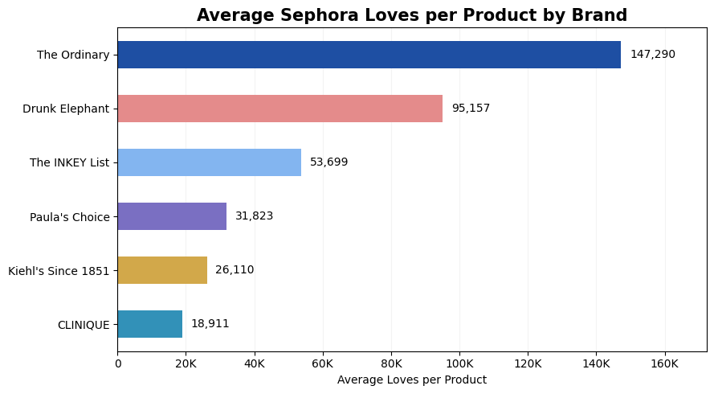

```python
import matplotlib.pyplot as plt
from matplotlib.ticker import FuncFormatter

# Calculate average Sephora Loves per product
loves_plot = (
    analysis_df.groupby("brand_name")["loves_count"]
    .mean()
    .sort_values()
)

# Match brand colors
bar_colors = [
    brand_colors[brand]
    for brand in loves_plot.index
]

# Create chart
fig, ax = plt.subplots(figsize=(9, 5))

loves_plot.plot(
    kind="barh",
    ax=ax,
    color=bar_colors,
    edgecolor="none"
)

ax.set_title(
    "Average Sephora Loves per Product by Brand",
    fontsize=15,
    fontweight="bold"
)

ax.set_xlabel("Average Loves per Product")
ax.set_ylabel("")

# Add value labels
for i, value in enumerate(loves_plot):
    ax.text(
        value + 2500,
        i,
        f"{value:,.0f}",
        va="center",
        fontsize=10
    )

# Add space for labels
ax.set_xlim(0, loves_plot.max() * 1.17)

# Format X-axis (20K, 40K, 60K...)
ax.xaxis.set_major_formatter(
    FuncFormatter(lambda x, pos: f"{x/1000:.0f}K" if x >= 1000 else f"{x:.0f}")
)

ax.grid(axis="x", alpha=0.15)
ax.set_axisbelow(True)

plt.tight_layout()
plt.show()
```

### Initial Customer Response Observation

Customer response varies substantially depending on the metric used. Paula's Choice recorded the highest average product rating at 4.40, while Drunk Elephant generated the highest average review volume per rated product at approximately 1,114 reviews.

The Ordinary demonstrated particularly strong customer interest on Sephora, generating approximately 6.63 million total loves and an average of approximately 147K loves per product—the highest among the six competitors.

These results suggest that rating strength, review activity, and customer interest represent distinct dimensions of customer response and should not be interpreted as a single measure of brand performance.

## 3.4 Competitive Positioning

This section combines pricing, portfolio structure, and customer response to compare the competitive positions of the six selected skincare brands.

```python
positioning = pd.DataFrame({
    "Median_Price":
        analysis_df.groupby("brand_name")["price_usd"].median(),

    "Largest_Category_Share":
        category_share.max(axis=1),

    "Avg_Loves_Per_Product":
        analysis_df.groupby("brand_name")["loves_count"].mean(),

    "Avg_Rating":
        customer_response_df.groupby("brand_name")["rating"].mean()
}).round(2)

positioning
```

| brand_name | Median_Price | Largest_Category_Share | Avg_Loves_Per_Product | Avg_Rating |
| --- | --- | --- | --- | --- |
| CLINIQUE | 34.75 | 27.8 | 18910.58 | 4.03 |
| Drunk Elephant | 38.00 | 21.1 | 95157.32 | 4.13 |
| Kiehl's Since 1851 | 46.00 | 26.4 | 26110.34 | 4.24 |
| Paula's Choice | 37.00 | 35.1 | 31823.38 | 4.40 |
| The INKEY List | 12.99 | 46.3 | 53698.95 | 4.09 |
| The Ordinary | 10.00 | 73.3 | 147290.22 | 4.18 |

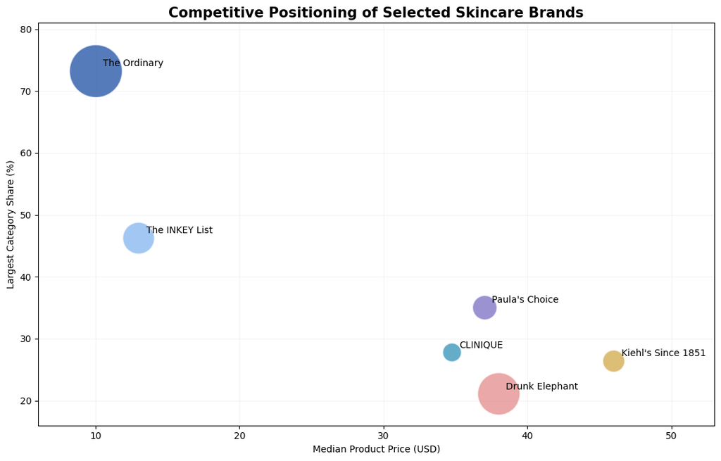

```python
import matplotlib.pyplot as plt

# Prepare positioning data
positioning = (
    analysis_df.groupby("brand_name")
    .agg(
        Median_Price=("price_usd", "median"),
        Avg_Loves_Per_Product=("loves_count", "mean"),
        Avg_Rating=("rating", "mean")
    )
)

positioning["Largest_Category_Share"] = category_share.max(axis=1)

positioning = positioning.round(2)

# Create chart
fig, ax = plt.subplots(figsize=(11, 7))

for brand, row in positioning.iterrows():

    ax.scatter(
        row["Median_Price"],
        row["Largest_Category_Share"],
        s=row["Avg_Loves_Per_Product"] / 45,
        color=brand_colors[brand],
        alpha=0.75,
        edgecolor="white",
        linewidth=1.5
    )

    ax.annotate(
        brand,
        (
            row["Median_Price"],
            row["Largest_Category_Share"]
        ),
        xytext=(8, 5),
        textcoords="offset points",
        fontsize=10
    )

ax.set_title(
    "Competitive Positioning of Selected Skincare Brands",
    fontsize=15,
    fontweight="bold"
)

ax.set_xlabel("Median Product Price (USD)")
ax.set_ylabel("Largest Category Share (%)")

# Add space around bubbles and labels
ax.set_xlim(6, 53)
ax.set_ylim(16, 81)

ax.grid(alpha=0.15)
ax.set_axisbelow(True)

plt.tight_layout()
plt.show()
```

### Competitive Positioning Observation

The competitive positioning analysis reveals distinct strategies among the six skincare brands.

The Ordinary occupies the most differentiated position, combining the lowest median price ($10.00), the highest portfolio specialization (73.3% in Treatments), and the highest average Sephora loves per product. The INKEY List follows a similar accessible, treatment-focused strategy, although with lower customer interest.

At the higher-price end, CLINIQUE, Kiehl's Since 1851, and Drunk Elephant maintain more diversified portfolios. Drunk Elephant stands out within this group for substantially higher average Sephora loves per product.

Paula's Choice occupies an intermediate position, combining higher pricing with a relatively treatment-focused portfolio and the highest average product rating among the six competitors.

Overall, the analysis suggests that competitors differentiate not only through price, but also through portfolio specialization and patterns of customer response.

## 3.5 Competitive Opportunity Analysis

This section evaluates category-level competition, pricing, and customer response to identify potential areas for differentiation across the selected skincare competitors.

```python
core_categories = [
    "Treatments",
    "Moisturizers",
    "Cleansers",
    "Eye Care",
    "Sunscreen"
]

core_df = analysis_df[
    analysis_df["secondary_category"].isin(core_categories)
].copy()
```

```python
category_opportunity = core_df.groupby(
    "secondary_category"
).agg(
    Product_Count=("product_id", "count"),
    Brand_Count=("brand_name", "nunique"),
    Median_Price=("price_usd", "median"),
    Avg_Price=("price_usd", "mean"),
    Avg_Loves_Per_Product=("loves_count", "mean")
).round(2)

category_ratings = (
    customer_response_df[
        customer_response_df["secondary_category"].isin(core_categories)
    ]
    .groupby("secondary_category")
    .agg(
        Avg_Rating=("rating", "mean"),
        Avg_Reviews_Per_Product=("reviews", "mean")
    )
    .round(2)
)

category_opportunity = category_opportunity.join(category_ratings)

category_opportunity.sort_values(
    "Product_Count",
    ascending=False
)
```

| secondary_category | Product_Count | Brand_Count | Median_Price | Avg_Price | Avg_Loves_Per_Product | Avg_Rating | Avg_Reviews_Per_Product |
| --- | --- | --- | --- | --- | --- | --- | --- |
| Treatments | 95 | 6 | 19.8 | 31.13 | 92129.47 | 4.19 | 682.49 |
| Moisturizers | 62 | 6 | 44.0 | 46.32 | 36725.92 | 4.07 | 559.60 |
| Cleansers | 61 | 6 | 25.0 | 24.91 | 44913.90 | 4.28 | 652.30 |
| Eye Care | 21 | 6 | 39.0 | 41.62 | 45821.38 | 3.96 | 876.00 |
| Sunscreen | 12 | 5 | 33.0 | 34.17 | 19909.17 | 3.96 | 352.92 |

```python
accessible_brands = [
    "The Ordinary",
    "The INKEY List"
]

higher_priced_brands = [
    "CLINIQUE",
    "Kiehl's Since 1851",
    "Drunk Elephant",
    "Paula's Choice"
]

core_df["Price_Position"] = core_df["brand_name"].apply(
    lambda x: "Accessible"
    if x in accessible_brands
    else "Higher-Priced"
)
```

```python
category_positioning = pd.crosstab(
    core_df["secondary_category"],
    core_df["Price_Position"]
)

category_positioning["Total"] = category_positioning.sum(axis=1)

category_positioning
```

| Price_Position secondary_category | Accessible | Higher-Priced | Total |
| --- | --- | --- | --- |
| Cleansers | 13 | 48 | 61 |
| Eye Care | 4 | 17 | 21 |
| Moisturizers | 11 | 51 | 62 |
| Sunscreen | 1 | 11 | 12 |
| Treatments | 52 | 43 | 95 |

[figure not shown]

```python
import matplotlib.pyplot as plt
from matplotlib.ticker import FuncFormatter

# Create chart
fig, ax = plt.subplots(figsize=(10, 6))

for category, row in category_opportunity.iterrows():

    ax.scatter(
        row["Product_Count"],
        row["Avg_Loves_Per_Product"],
        s=300,
        color=portfolio_colors[category],
        alpha=0.85,
        edgecolor="white",
        linewidth=1.5
    )

    ax.annotate(
        category,
        (
            row["Product_Count"],
            row["Avg_Loves_Per_Product"]
        ),
        xytext=(8, 5),
        textcoords="offset points",
        fontsize=10
    )

ax.set_title(
    "Category Competition and Customer Interest",
    fontsize=15,
    fontweight="bold"
)

ax.set_xlabel("Number of Products")
ax.set_ylabel("Average Sephora Loves per Product")

# Add margins
ax.set_xlim(5, 110)
ax.set_ylim(10000, 105000)

# Format Y-axis
ax.yaxis.set_major_formatter(
    FuncFormatter(
        lambda x, pos: f"{x/1000:.0f}K"
    )
)

ax.grid(alpha=0.15)
ax.set_axisbelow(True)

plt.tight_layout()
plt.show()
```

### Competitive Opportunity Observation

Treatments represent the most competitive core category, with 95 products across all six brands. However, the category also generates the highest average Sephora loves per product, indicating strong customer interest despite substantial competitive intensity. Accessible-positioned brands are particularly concentrated in this category, contributing 52 of the 95 treatment products.

In contrast, Sunscreen is the least represented core category, with only 12 products across five brands and just one product from the accessible-positioned competitors. This suggests potential portfolio whitespace at the accessible end of the market. However, Sunscreen also records relatively lower customer-response metrics, so the available data does not establish strong unmet demand.

Cleansers present a more balanced competitive profile, combining relatively strong average ratings (4.28) and customer interest with broader representation across all six brands.

Overall, category whitespace alone should not be interpreted as a market opportunity. Potential expansion areas should be evaluated alongside customer response and competitive intensity.

# 4. Key Findings & Strategic Recommendations

The competitive analysis reveals distinct strategies across pricing, portfolio structure, and customer response. The following findings summarize the most important competitive patterns and their potential strategic implications.

### Finding 1 — The market shows a clear pricing divide

The Ordinary and The INKEY List occupy distinctly accessible price positions, with median product prices of $10.00 and $12.99, respectively. The remaining four competitors have substantially higher median prices ranging from $34.75 to $46.00.

**Recommendation:**  
A brand entering or repositioning within this competitive set should establish a clear price position rather than competing broadly across both accessible and higher-priced segments. Pricing should reinforce the intended brand proposition and product strategy.

### Finding 2 — Portfolio specialization is a major source of differentiation

The Ordinary demonstrates the strongest category specialization, with 73.3% of its portfolio concentrated in Treatments. The INKEY List is also treatment-focused at 46.3%, while brands such as CLINIQUE, Kiehl's Since 1851, and Drunk Elephant maintain more diversified portfolios.

**Recommendation:**  
Brands should determine whether differentiation is better supported by category specialization or broader skincare coverage. A focused portfolio can create a clearer product identity, while diversification may support a wider range of customer needs.

### Finding 3 — Customer response varies by competitive strategy

No single competitor leads across all customer-response metrics. Paula's Choice records the highest average product rating at 4.40, Drunk Elephant generates the highest average review volume per rated product, and The Ordinary generates the highest average Sephora loves per product at approximately 147K.

**Recommendation:**  
Competitive performance should be evaluated using multiple customer-response measures rather than a single metric. Ratings can indicate product satisfaction, while review activity and Sephora loves provide additional signals of customer interaction and interest.

### Finding 4 — Portfolio whitespace does not automatically indicate demand

Treatments are the most heavily represented core category, with 95 products, but also generate the highest average Sephora loves per product. Sunscreen is comparatively underrepresented—particularly among accessible-positioned competitors—but shows weaker customer-response metrics within the available data.

**Recommendation:**  
Potential portfolio expansion should consider both competitive whitespace and evidence of customer interest. Underrepresented categories should be validated with additional demand, trend, or sales data before being treated as growth opportunities.

## Conclusion

The analysis demonstrates that the six selected skincare competitors follow meaningfully different strategies across pricing, portfolio structure, and customer response.

The Ordinary and The INKEY List compete through accessible pricing and treatment-focused portfolios, while several higher-priced competitors maintain broader category coverage. Customer-response patterns further demonstrate that strong ratings, review activity, and customer interest do not necessarily occur within the same brands.

For a skincare brand evaluating its competitive position, the results suggest that differentiation should be built around a deliberate combination of price position, portfolio focus, and customer value proposition rather than any single competitive dimension.

The analysis also highlights the importance of distinguishing competitive whitespace from demonstrated market opportunity. Additional sales, market-size, and consumer-demand data would be required before making investment or market-entry decisions.